# Task 2 : Car Price Prediction using Machine Learning

## 6. Model Building

```python
# Initialize Random Forest model
rf_model = RandomForestRegressor(n_estimators=100, random_state=42)
```

```python
# Create the SequentialFeatureSelector object
sfs = SequentialFeatureSelector(
    rf_model,
    n_features_to_select = 6,  # features to select
    direction ='forward',  # Forward selection
    scoring ='neg_root_mean_squared_error',  # scoring metric
    cv=5  # 5-fold cross-validation
)

# Fit the selector
sfs.fit(X_train_transformed, y_train)
```

```
SequentialFeatureSelector(estimator=RandomForestRegressor(random_state=42),
                          n_features_to_select=6,
                          scoring='neg_root_mean_squared_error')
```

```python
#  Retrieve the selected feature mask from SFS
selected_features_mask = sfs.get_support(indices = True)  # Boolean mask of selected features

#  Subset the scaled training and test data with selected features
X_train_selected = X_train_transformed[:, selected_features_mask]
X_test_selected = X_test_transformed[:, selected_features_mask]
```

```python
# Get selected feature names
selected_feature_names = np.array(all_feature_names)[sfs.get_support()]
selected_feature_names
```

```
array(['Present_Price', 'Driven_kms', 'Fuel_Type_Diesel',
       'Fuel_Type_Petrol', 'Selling_type_Dealer', 'Transmission_Manual'],
      dtype='<U23')
```

```python
# Print the number of selected features
print("Number of selected features:", len(selected_features_mask))
```

```
Number of selected features: 6
```

```python
# Train the RandomForest model with the selected features
rf_model.fit(X_train_selected, y_train)
```

```
RandomForestRegressor(random_state=42)
```

```python
# Make predictions
y_pred_train = rf_model.predict(X_train_selected)
y_pred_test = rf_model.predict(X_test_selected)
```

```python
y_pred_test
```

```
array([ 2.9195    ,  0.5484    ,  4.5215    ,  0.7856    ,  4.26966667,
        4.035     , 10.6669    ,  5.7695    ,  7.8781    ,  0.3943    ,
        1.631     ,  5.461     ,  5.755     ,  5.3135    , 10.369     ,
        0.7835    ,  4.548     ,  6.0715    ,  1.1439    ,  4.4465    ,
        2.5335    ,  4.6833    ,  5.2455    ,  2.893     ,  6.349     ,
        8.4865    ,  0.2195    ,  1.662     ,  5.8811    ,  0.5248    ,
        1.9245    ,  0.8056    ,  3.1025    ,  0.5418    ,  0.2072    ,
        7.793     ,  6.7339    , 10.6669    ,  6.232     ,  3.8375    ,
        5.835     ,  0.4773    ,  9.352     ,  3.381     ,  0.54226667,
        0.43885   ,  2.299     ,  6.6845    ,  4.9605    ,  0.8308    ,
        1.0265    ,  7.9505    ,  0.2669    ,  6.995     ,  0.2084    ])
```

## 7. Model Evaluation

```python
# Evaluation for the Training Set
train_mae = mean_absolute_error(y_train, y_pred_train)
train_mse = mean_squared_error(y_train, y_pred_train)
train_rmse = np.sqrt(train_mse)
train_r2 = r2_score(y_train, y_pred_train)
train_accuracy = int(train_r2 * 100)

# Evaluation for the Test Set
test_mae = mean_absolute_error(y_test, y_pred_test)
test_mse = mean_squared_error(y_test, y_pred_test)
test_rmse = np.sqrt(test_mse)
test_r2 = r2_score(y_test, y_pred_test)
test_accuracy = int(test_r2 * 100)

# Print Training Metrics
print("Training Metrics:")
print(f"Root Mean Squared Error (Train): {train_rmse}")
print(f"Mean Squared Error (Train): {train_mse}")
print(f"Mean Absolute Error (Train): {train_mae}")
print(f"R-squared (Train): {train_r2}")
print(f'Accuracy (Train): {train_accuracy}%')

# Print Testing Metrics
print("\nTesting Metrics:")
print(f"Root Mean Squared Error (Test): {test_rmse}")
print(f"Mean Squared Error (Test): {test_mse}")
print(f"Mean Absolute Error (Test): {test_mae}")
print(f"R-squared (Test): {test_r2}")
print(f'Accuracy (Test): {test_accuracy}%')
```

```
Training Metrics:
Root Mean Squared Error (Train): 0.4120947028852055
Mean Squared Error (Train): 0.1698220441460458
Mean Absolute Error (Train): 0.24201472402597393
R-squared (Train): 0.9803327907263959
Accuracy (Train): 98%

Testing Metrics:
Root Mean Squared Error (Test): 1.195899066467054
Mean Squared Error (Test): 1.4301745771767709
Mean Absolute Error (Test): 0.7583748484848492
R-squared (Test): 0.8794664875504177
Accuracy (Test): 87%
```

### FINE TUNE MODEL

```python
# Define the parameter grid
param_grid = {
    'n_estimators': [50, 100, 200],  # Number of trees in the forest
    'max_depth': [None, 10, 20, 30],  # Maximum depth of each tree
    'min_samples_split': [2, 5, 10], # Minimum number of samples required to split an internal node
    'min_samples_leaf': [1, 2, 4]
}
```

```python
# Create the GridSearchCV object
grid_search = GridSearchCV(
    estimator = rf_model,          # RandomForestRegressor model
    param_grid = param_grid,       # Parameter grid
    scoring ='neg_root_mean_squared_error',  # Scoring metric
    cv=5,                        # Number of cross-validation folds
    n_jobs = -1,                   # Use all available cores
    verbose = 2                    # Print progress
)
```

```python
# Fit GridSearchCV
grid_search.fit(X_train_selected, y_train)
```

```
Fitting 5 folds for each of 108 candidates, totalling 540 fits
```

```
GridSearchCV(cv=5, estimator=RandomForestRegressor(random_state=42), n_jobs=-1,
             param_grid={'max_depth': [None, 10, 20, 30],
                         'min_samples_leaf': [1, 2, 4],
                         'min_samples_split': [2, 5, 10],
                         'n_estimators': [50, 100, 200]},
             scoring='neg_root_mean_squared_error', verbose=2)
```

```python
# Best parameters and score
best_params = grid_search.best_params_
best_score = grid_search.best_score_

print("Best parameters found: ", grid_search.best_params_)
print("Best score found: ", grid_search.best_score_)
```

```
Best parameters found:  {'max_depth': 10, 'min_samples_leaf': 2, 'min_samples_split': 2, 'n_estimators': 200}
Best score found:  -1.03626321658012
```

```python
# Create a new RandomForestRegressor with the best parameters
best_rf_model = RandomForestRegressor(**best_params)

# Fit the model with the selected features
best_rf_model.fit(X_train_selected, y_train)
```

```
RandomForestRegressor(max_depth=10, min_samples_leaf=2, n_estimators=200)
```

```python
# Evaluate the best model on the training and test sets
y_pred_train_best = best_rf_model.predict(X_train_selected)
y_pred_test_best = best_rf_model.predict(X_test_selected)
```

```python
train_mae_best = mean_absolute_error(y_train, y_pred_train_best)
train_mse_best = mean_squared_error(y_train, y_pred_train_best)
train_rmse_best = np.sqrt(train_mse_best)
train_r2_best = r2_score(y_train, y_pred_train_best)
train_accuracy_best = int(train_r2_best * 100)

test_mae_best = mean_absolute_error(y_test, y_pred_test_best)
test_mse_best = mean_squared_error(y_test, y_pred_test_best)
test_rmse_best = np.sqrt(test_mse_best)
test_r2_best = r2_score(y_test, y_pred_test_best)
test_accuracy_best = int(test_r2_best * 100)
```

```python
# Define the metrics
metrics = {
    'Metric': [
        'Root Mean Squared Error', 'Mean Squared Error', 'Mean Absolute Error',
        'R-squared', 'Accuracy'
    ],
    'Training Metrics': [
        train_rmse_best, train_mse_best, train_mae_best, train_r2_best, f'{train_accuracy_best}%'
    ],
    'Testing Metrics': [
        test_rmse_best, test_mse_best, test_mae_best, test_r2_best, f'{test_accuracy_best}%'
    ]
}

# Create a DataFrame
metrics_df = pd.DataFrame(metrics)

# Print the DataFrame
print("Best Parameters:", best_params)
print("\nModel Performance Metrics:")
metrics_df
```

```
Best Parameters: {'max_depth': 10, 'min_samples_leaf': 2, 'min_samples_split': 2, 'n_estimators': 200}

Model Performance Metrics:
```

|  | Metric | Training Metrics | Testing Metrics |
| --- | --- | --- | --- |
| 0 | Root Mean Squared Error | 0.560993 | 1.117794 |
| 1 | Mean Squared Error | 0.314714 | 1.249463 |
| 2 | Mean Absolute Error | 0.340537 | 0.733326 |
| 3 | R-squared | 0.963553 | 0.894697 |
| 4 | Accuracy | 96% | 89% |

### VISUALIING OUR RESULTS WITH ACTUAL VALUES

```python
# Calculate residuals
residuals = y_test - y_pred_test_best
```

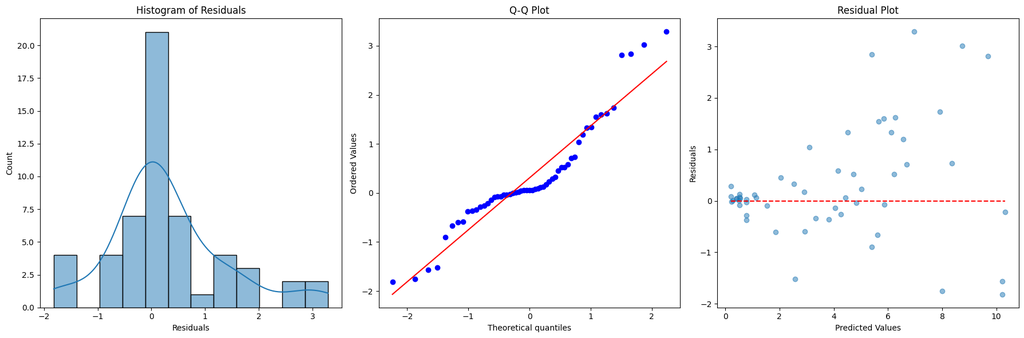

```python
# 3 subplots arranged in 1 row and 3 columns
fig, axs = plt.subplots(1, 3, figsize=(18, 6))

# Histogram of Residuals
sns.histplot(residuals, kde=True, ax=axs[0])
axs[0].set_xlabel('Residuals')
axs[0].set_title('Histogram of Residuals')

# Q-Q Plot
stats.probplot(residuals, dist="norm", plot=axs[1])
axs[1].set_title('Q-Q Plot')

# Residual Plot
axs[2].scatter(y_pred_test_best, residuals, alpha=0.5)
axs[2].hlines(y=0, xmin=min(y_pred_test_best), xmax=max(y_pred_test_best), colors='r', linestyles='--')
axs[2].set_xlabel('Predicted Values')
axs[2].set_ylabel('Residuals')
axs[2].set_title('Residual Plot')

# Adjust layout
plt.tight_layout()
plt.savefig('RESIDUAL ANALYSIS')
plt.show()
```

## RESIDUAL ANALYSIS

Overall, the graphs suggest that the model is a reasonable fit for the data, but further analysis may be needed to identify any potential issues.

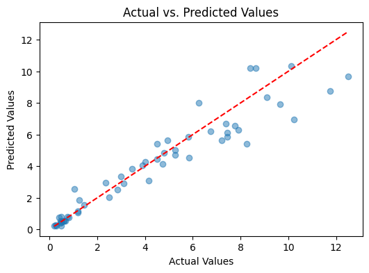

```python
# Actual values vs Predicted values
plt.figure(figsize=(6, 4))
plt.scatter(y_test, y_pred_test_best, alpha=0.5)
plt.plot([min(y_test), max(y_test)], [min(y_test), max(y_test)], color='r', linestyle='--')
plt.xlabel('Actual Values')
plt.ylabel('Predicted Values')
plt.title('Actual vs. Predicted Values')
plt.savefig('Actual vs Predicted Values')
plt.show()
```

## ACTUAL VS PREDICTED VALUES

- the points are clustered closely around the red line, it indicates a good fit between the model and the data.
- In this case, while there is some scatter, the points seem to follow the red line fairly well, suggesting a reasonable fit.
- Overall, the plot suggests that the model is a reasonable fit for the data, but further analysis may be needed to identify any potential issues.

## Model Performance Summary

### Best Parameters

- **Max Depth**: 10
- **Min Samples Leaf**: 2
- **Min Samples Split**: 2
- **Number of Estimators**: 200

### Training Metrics (Best Model)

- **Root Mean Squared Error (RMSE)**: 0.561
- **Mean Squared Error (MSE)**: 0.315
- **Mean Absolute Error (MAE)**: 0.341
- **R-squared (R²)**: 0.964
- **Accuracy**: 96%

### Testing Metrics (Best Model)

- **Root Mean Squared Error (RMSE)**: 1.118
- **Mean Squared Error (MSE)**: 1.249
- **Mean Absolute Error (MAE)**: 0.733
- **R-squared (R²)**: 0.895
- **Accuracy**: 89%

The **Random Forest model** with the optimized hyperparameters demonstrates strong performance both on training and testing datasets. The training metrics indicate a **high level of accuracy and low error rates**, suggesting that the model fits the training data well. The testing metrics show that the model performs well on unseen data, maintaining a high R-squared value and reasonable error metrics. **Overall, the model appears to be robust and effective for car price prediction.**

### IMPORTANT FEATURES OF OUR MODEL

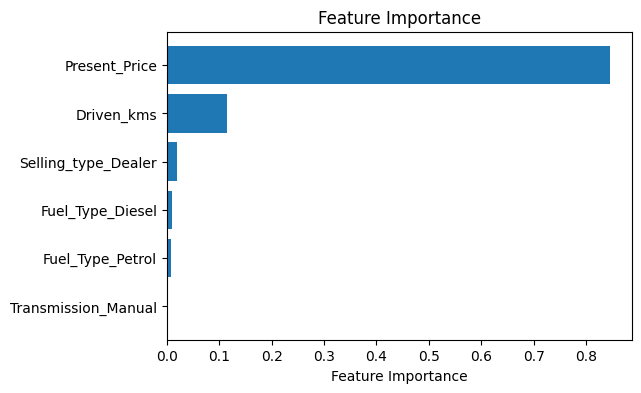

```python
importances = best_rf_model.feature_importances_

# Plotting
plt.figure(figsize=(6,4))
indices = np.argsort(importances)
plt.barh(range(len(indices)), importances[indices], align='center')
plt.yticks(range(len(indices)), selected_feature_names[indices])
plt.xlabel('Feature Importance')
plt.title('Feature Importance')
plt.savefig('Feature Importances')
plt.show()
```

### SAVE THE MODEL, SCALER, FEATURE SELECTOR & ENCODER

```python
# Save the DataFrame to a CSV file
metrics_df.to_csv('model_performance_metrics.csv', index=False)

print("Metrics saved to 'model_performance_metrics.csv'")
```

```
Metrics saved to 'model_performance_metrics.csv'
```

```python
# Save the trained RandomForestRegressor model
with open('random_forest_model.pkl', 'wb') as model_file:
    pickle.dump(best_rf_model, model_file)

# Save the ColumnTransformer
with open('column_transformer.pkl', 'wb') as preprocessor_file:
    pickle.dump(preprocessor, preprocessor_file)

# Save the SequentialFeatureSelector
with open('sfs.pkl', 'wb') as sfs_file:
    pickle.dump(sfs, sfs_file)

print("Model, ColumnTransformer, and SFS saved successfully.")
```

```
Model, ColumnTransformer, and SFS saved successfully.
```

## 8. Conclusion

### DEFINE AND TEST OUR MODEL ON TEST PARAMETERS

```python
def predict_car_price(present_price, driven_kms, year, fuel_type, selling_type, transmission, owner):
    """
    Function to predict car price based on input features.

    Parameters:
    - present_price: Present price of the car (in thousand dollars).
    - driven_kms: Kilometers driven by the car.
    - year: Year of manufacture of the car.
    - fuel_type: Fuel type of the car (either 'Petrol', 'Diesel', or 'CNG').
    - selling_type: Selling type of the car (either 'Dealer' or 'Individual').
    - transmission: Transmission type (either 'Manual' or 'Automatic').
    - owner: Number of previous owners (1, 2, 3, 4).

    Returns:
    - estimated_price: Predicted price of the car.
    """

    # Calculate the car's age from the year of manufacture
    current_year = datetime.datetime.now().year
    car_age = current_year - year

    # Create a dictionary for the input data with the correct column names
    data = {
        'Present_Price': [present_price],
        'Driven_kms': [driven_kms],
        'Car_Age': [car_age],  # Use car age instead of year
        'Fuel_Type': [fuel_type],
        'Selling_type': [selling_type],
        'Transmission': [transmission],
        'Owner': [owner]  # Owner is now numerical
    }

    # Convert the dictionary to a pandas DataFrame
    input_df = pd.DataFrame(data)

    # Transform the input data using the preprocessor (with handle_unknown='ignore')
    transformed_data = preprocessor.transform(input_df)

    # Apply the feature selector (SFS) to select important features
    selected_features = sfs.transform(transformed_data)

    # Use the model to predict the car price
    estimated_price = model.predict(selected_features)[0]

    return estimated_price
```

### LOAD THE SaVED MODEL

```python
import pickle
import pandas as pd

# Load the trained RandomForestRegressor model
with open('random_forest_model.pkl', 'rb') as model_file:
    model = pickle.load(model_file)

# Load the ColumnTransformer
with open('column_transformer.pkl', 'rb') as preprocessor_file:
    preprocessor = pickle.load(preprocessor_file)

# Load the SequentialFeatureSelector
with open('sfs.pkl', 'rb') as sfs_file:
    sfs = pickle.load(sfs_file)
```

### TEST FUNCTION

```python
# Example input values
present_price = 5.59  # in thousand dollars
driven_kms = 27000  # kilometers
year = 2014  # year of manufacture
fuel_type = 'CNG'  # 'Petrol', 'Diesel', or 'CNG'
selling_type = 'Dealer'  # 'Dealer' or 'Individual'
transmission = 'Manual'  # 'Manual' or 'Automatic'
owner = 1  # Number of previous owners (e.g., 1 for 'First owner')

# Predict the car price
predicted_price = predict_car_price(present_price, driven_kms, year, fuel_type, selling_type, transmission, owner)

print(f"The estimated price of the car is ${predicted_price:.2f} thousand.")
```

```
The estimated price of the car is $3.98 thousand.
```

```python
df.sample()
```

|  | Year | Selling_Price | Present_Price | Driven_kms | Fuel_Type | Selling_type | Transmission | Owner |
| --- | --- | --- | --- | --- | --- | --- | --- | --- |
| 49 | 2017 | 7.75 | 9.29 | 37000 | Petrol | Dealer | Automatic | 0 |

## 9. Future Work

- Further improvements could involve exploring additional feature engineering techniques or experimenting with different machine learning algorithms.
- Conducting more extensive hyperparameter tuning and cross-validation could further enhance model performance.
- Handling Skew: Consider transforming the target variable to reduce the impact of outliers.

### Summary

In summary, the project successfully refined a Random Forest Regressor model for predicting selling prices, achieving robust performance metrics and demonstrating the value of feature selection and hyperparameter optimization in improving predictive accuracy.

## ** DEPLOYMENT USING FLASK**